# My Black Counts: Outreach Experiment

Advancement Project California

8/13/2020

### Research Question

#### Primary question:

1. Did treatment zip codes (zip codes that were targeted with digital outreach) have larger response rate gains than control zip codes (zip codes that received no targeted digital outreach)?

#### Secondary questions:

2. Are there any variables correlated with higher response rate gains?
3. Are there differences by county (Alameda vs. Los Angeles)?
4. Are there additional contextual factors to consider? E.g. phone banking outreach from MBC

### Experiment Summary

- About twenty zip codes were selected each from Alameda County (21) and Los Angeles County (19).
- The zip codes were selected for having larger shares of Black households and for being statistically similar. While the demographics from each zip code are not exactly the same, the group selected has minimal within-group variation as compared to other zip codes in the county.
- Within each group of selected zip codes treatment and control zip codes were randomly assigned. Treatment zip codes were targeted with digital outreach while control zip codes were not.
- The experiment ran from 7/19 to 7/26.
- The goal is to look for correlation between digital outreach and response rate gains during the same time period. Because responses could take around 48 hours to appear in the data, we look at response rate gains from 7/17 (the Friday before the start of the experiment–response rates are no longer published during the weekends) to 7/29 (allowing time for responses to appear in the Census response rate data).

## I. Locations of Selected ZIP Codes

#### Los Angeles County ZIP Codes

| city | Number of ZIP Codes |
| --- | --- |
| Carson | 2 |
| Compton | 3 |
| Gardena | 1 |
| Inglewood | 3 |
| Los Angeles | 10 |

19 ZIP codes selected in Los Angeles County

#### Alameda County ZIP Codes

| city | Number of ZIP Codes |
| --- | --- |
| Hayward | 3 |
| Oakland | 15 |
| San Leandro | 3 |

21 ZIP Codes selected in Alameda County

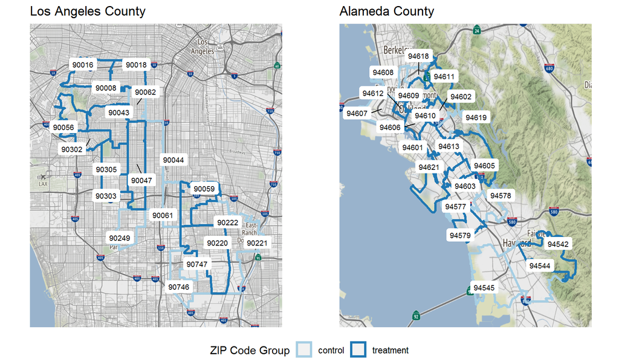

## II. Review Outreach Metrics in Treatment ZIP Codes

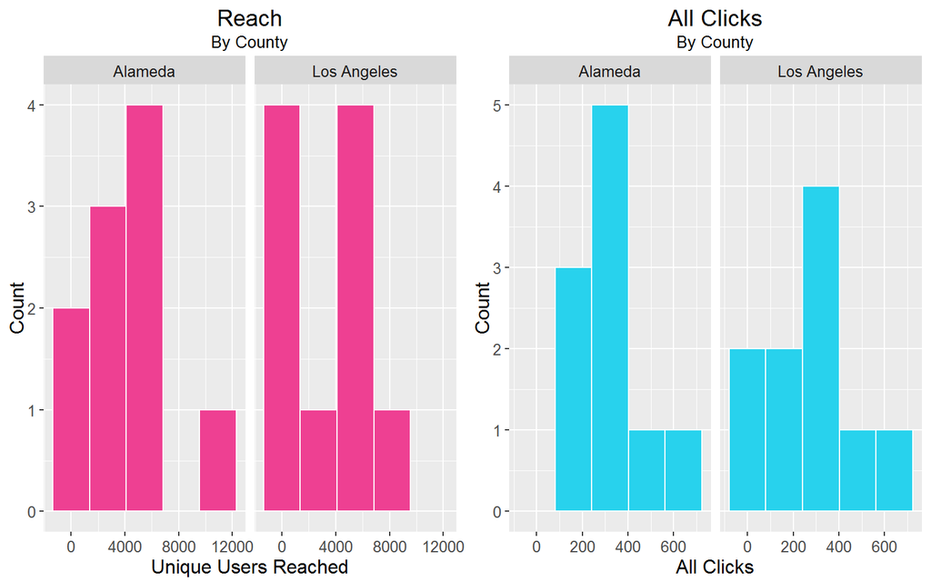

## III. Review Response Rates

### Average Response Rate Gains by ZIP Code Group

- On average, treatment ZIP codes (those that were targeted with digital outreach) in Alameda County gained about **0.05 percentage points more** than control ZIP codes in the county.
- On average, treatment ZIP codes (those that were targeted with digital outreach) in Los Angeles County gained about **0.009 percentage points less** than control ZIP codes in the county.
- At this period in the enumeration, self-response rate gains across the state were very small. The state overall only gained about 0.7 percentage points during this period, and so even response rate gains that are relatively small are significant during this time.

| County | Control (%) | Treatment (%) |
| --- | --- | --- |
| Alameda | 0.735 | 0.782 |
| Los Angeles | 0.678 | 0.669 |

### Visualizing Response Rate Gains

- Whether we look at unique users reached or clicks, in general we see that response rate gains in treatment ZIP codes in Alameda County are more strongly associated with digital outreach than treatment ZIP codes in Los Angeles.
- Overall, treatment ZIP Codes in Alameda County had a higher percentage point gain than those in Los Angeles County.
- The confidence intervals (the gray band around the trend line) are quiet large, indicating that the correlation between response rate gains and outreach is not certain. If we were to extend the trend line to more users reached or more clicks, we may be just as likely to see higher response rate gains as lower response rate gains.
- This may be because, as Lanae Norwood mentioned previously, there may be more digital ‘noise’ to cut through in Los Angeles County than in Alameda County regarding outreach to Black residents.
- Or it may be because Los Angeles County is harder to count than Alameda County–while Alameda County has its share of hard-to-count communities, Los Angeles County overall has lower rates of internet access, higher rates of people living below the poverty line, etc.

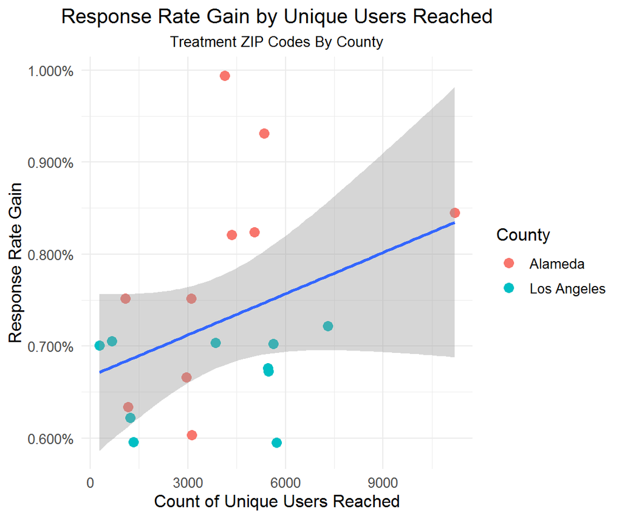

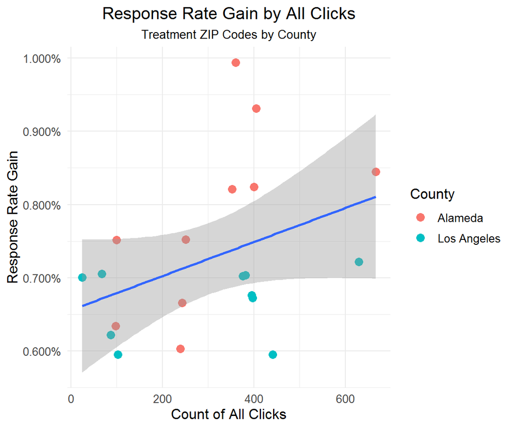

When the county data are disaggregated, we see substantially different trend lines by county. Treatment ZIP codes in Alameda County show a much stronger positive relationship between response rate gains and outreach than ZIP codes in Los Angeles County.

### Response Rate Gain by Unique Users Reached

#### Treatment ZIP Codes By County

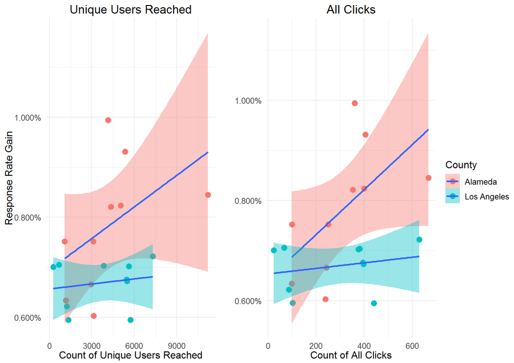

### Increase in Self-Response Rate By County

#### From 7/17 to 7/29

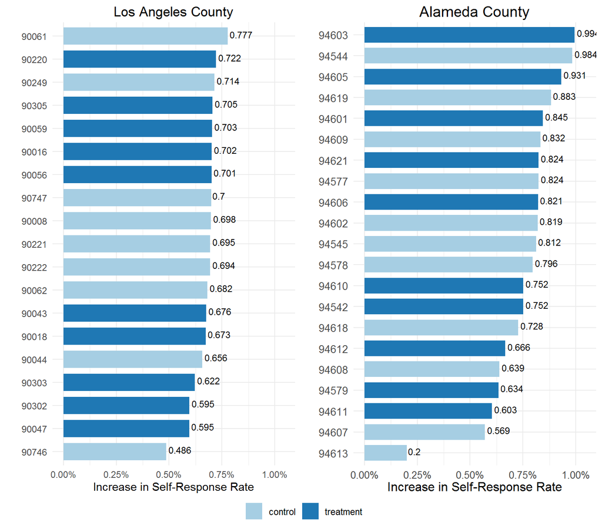

*Digital outreach targeted treatment ZIP codes from 7/19-7/26. As self-response rates are not published on the weekend, the first day of response rates is from the Friday before outreach began. Because it could take about 48 hours to see responses reflected in the self-response rate data, we include self-response rates up to two days after the experiement ended.*

### Correlation of Response Rate Gain with other Variables

- Response rate gain (the increase in response rate during the experiment period) does not show a strong correlation with any variable. It does have a small positive correlation (0.2) with the number of users reached and the number of clicks via digital outreach, as well as a small positive correlation (0.3) with the percentage of Black renters in a ZIP code.
- Interestingly, there is no correlation (0) between response rate gain and the response rate of the ZIP code at the end the experiment–meaning that ZIP codes with low self-response rates were just as likely to gain counted households during the experiment as ZIP codes with high self-response rates.
- Response rate at the end of the experiment shows moderately strong negative correlation with the share of Black households without internet (-0.6) and the share of the Black population living below the poverty line (-0.7). These are two key hard-to-count factors that are strongly associated with lower propenstiy to self-respond to the Census, so this negative correlation is expected.
- The digital outreach metrics (users reached and all clicks) are slightly positively correlated with Black households without internet access and poverty rate (0.3), and are slightly negatively correlated with the response rate at the end of the experiment (-0.3). This indicates that digital outreach was targeted to areas with a harder-to-count Black population, as intended.
- There are strong correlations between associated variables–we see that the share of renters is positively correlated with the share of people living in multiunit structures (which is expected as apartment buildings are often inhabitated by renters), and the poverty rate is correlated with lack of internet access/broadband subscription (which is also expected given the cost of broadband subscription).

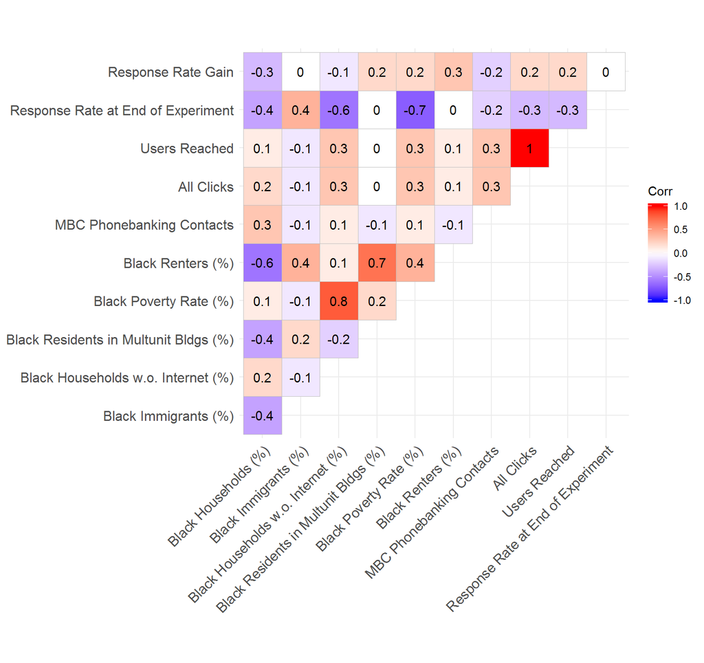

## IV. Summary

- *1. Did treatment zip codes have larger response rate gains than control zip codes?*
  - There are general linear trends indicating a positive relationship with outreach (clicks and users reached) and response rate gain during the experiment, but there is a good deal of variation in the data and the trends are not statistically significant. Outreach is targeted to the hardest-to-count communities, and these communities are indeed hard to count.
- *2. Are there any variables correlated with higher response rate gains?*
  - Some Demographic and outreach variables showed some correlation with the response rate gain. The response rate gain has a small positive correlation (0.2) with outreach (the number of users reached and the number of clicks).
  - There was also a small positive correlation (0.3) with the percentage of Black renters in a ZIP code, and with the share of Black households that are located in multiunit structures and that live below the poverty line (0.2). This may be because these are several hard-to-count characteristics, and outreach was targeted hard-to-count communities.
- *3. Are there differences by county (Alameda vs. Los Angeles)?*
  - Yes, Alameda County shows much more variation across treament and control ZIP codes than LA County, but also a generally stronger positive association between response rate gains and outreach. Alameda County ZIP codes also had larger response rate gains (maximum gain 0.99) than Los Angeles County ZIP codes (where the maximum gain was 0.78).
- *4. Are there additional contextual factors to consider? E.g. phone banking outreach from MBC*
  - The phone banking outreach during the same period has a small negative correlation (-0.2) with response rate gains and overall response rate at the end of the period, which may indicate that phone banking was being targeted to the lowest-responding, hardest-to-count regions.
  - When reviewing a linear regression model of the ZIP codes where the outcome/dependent variable is response rate gain, the two variables with the most explanatory power were lack of internet access and poverty rate. The model formula was:

    Response Rate Gain = Lack of Internet Access + Poverty Rate + Outreach
  - Lack of internet access had a small negative association with the outcome, indicating that as the percent of the population without internet increases, response rate gains decrease. Poverty rate had a small positive association with the outcome, indicating that as the percent of the population living below the poverty line increases, the response rate gains in this time period increase as well. If poverty rate can be used as a proxy variable for many other hard-to-count charactersistics, this may be because there is such a concentrated effort to do outreach in hard-to-count areas by community organizations. In this way, although digital outreach during this time period did not show a strong statistical relationship with response rate gain, the poverty rate variable may represent community investment by many different CBOs and campaigns, including My Black Counts.
  - Lastly, while these two variables were the best predictors for response rate gain in a statistical sense, in the real world the relationship between outreach and action is more complicated. For example, we track response rates several days after the end of the outreach period in order to allow time for the US Census Bureau to include new responses in their data, but if someone is clicks on a social media link and then waits a few days to act on it, their response may not be captured in our response rate data window. Additionally, while the USCB initially said that responses are reflected in the response rate data in 24 hours, there could very possibly be system delays on their end that we would not know about.